# IMDb Movie Review Sentiment Analysis

Binary Sentiment Classification of IMDb Movie Reviews

OKOSUN FAVOUR

2026-11-15

# 1 Project Overview

This project analyses IMDb movie reviews and classifies them as either positive or negative. It covers dataset exploration, data cleaning, text processing, exploratory text analysis, machine-learning model development, model evaluation, and model interpretation using LIME and a coefficient-based SHAP analysis.

The four models compared are Logistic Regression, Multinomial Naive Bayes, Linear Support Vector Machine (SVM), and Ridge-regularised Logistic Regression.

# 2 1. Setup: Install and Load Packages

This section checks for the packages required for the project and loads them. Package installation is performed only when a package is missing.

```r
required_packages <- c(
  "tidyverse", "tidytext", "wordcloud", "RColorBrewer",
  "text2vec", "glmnet", "e1071", "LiblineaR", "pROC", "lime"
)

missing_packages <- required_packages[
  !vapply(required_packages, requireNamespace, logical(1), quietly = TRUE)
]

if (length(missing_packages) > 0) {
  install.packages(
    missing_packages,
    repos = "https://cloud.r-project.org"
  )
}

library(tidyverse)
library(tidytext)
library(wordcloud)
library(RColorBrewer)
library(text2vec)
library(glmnet)
library(e1071)
library(LiblineaR)
library(pROC)
library(lime)
library(Matrix)
```

# 3 2. Import the Dataset

The IMDb review dataset is imported into R for analysis. Place the CSV file in the same folder as this R Markdown file and make sure its filename matches the one used below.

```r
reviews <- read.csv("IMDB Dataset.csv", stringsAsFactors = FALSE)

dim(reviews)
```

```
## [1] 50000     2
```

```r
names(reviews)
```

```
## [1] "review"    "sentiment"
```

```r
head(reviews)
```

|  | review | sentiment |
| --- | --- | --- |
| 1 | One of the other reviewers has mentioned that after watching just 1 Oz episode you'll be hooked. They are right, as this is exactly what happened with me.The first thing that struck me about Oz was it… | positive |
| 2 | A wonderful little production. The filming technique is very unassuming- very old-time-BBC fashion and gives a comforting, and sometimes discomforting, sense of realism to the entire piece. The actors… | positive |
| 3 | I thought this was a wonderful way to spend time on a too hot summer weekend, sitting in the air conditioned theater and watching a light-hearted comedy. The plot is simplistic, but the dialogue is wi… | positive |
| 4 | Basically there's a family where a little boy (Jake) thinks there's a zombie in his closet & his parents are fighting all the time.This movie is slower than a soap opera... and suddenly, Jake decides … | negative |
| 5 | Petter Mattei's "Love in the Time of Money" is a visually stunning film to watch. Mr. Mattei offers us a vivid portrait about human relations. This is a movie that seems to be telling us what money, p… | positive |
| 6 | Probably my all-time favorite movie, a story of selflessness, sacrifice and dedication to a noble cause, but it's not preachy or boring. It just never gets old, despite my having seen it some 15 or mo… | positive |

# 4 3. Initial Data Exploration

The dataset is inspected to understand its dimensions, column names, data types, summary statistics, sentiment distribution, missing values, and duplicate reviews.

```r
str(reviews)
```

```
## 'data.frame':    50000 obs. of  2 variables:
##  $ review   : chr  "One of the other reviewers has mentioned that after watching just 1 Oz episode you'll be hooked. They are right"| __truncated__ "A wonderful little production. <br /><br />The filming technique is very unassuming- very old-time-BBC fashion "| __truncated__ "I thought this was …
##  $ sentiment: chr  "positive" "positive" "positive" "negative" ...
```

```r
summary(reviews)
```

```
##        review          sentiment
##  Length   :50000   Length   :50000
##  N.unique :49582   N.unique :    2
##  N.blank  :    0   N.blank  :    0
##  Min.nchar:   32   Min.nchar:    8
##  Max.nchar:13704   Max.nchar:    8
```

```r
table(reviews$sentiment)
```

```
##
## negative positive
##    25000    25000
```

```r
colSums(is.na(reviews))
```

```
##    review sentiment
##         0         0
```

```r
sum(duplicated(reviews$review))
```

```
## [1] 418
```

```r
duplicate_reviews <- reviews[duplicated(reviews$review), ]
head(duplicate_reviews, 10)
```

|  | review | sentiment |
| --- | --- | --- |
| 3538 | Quite what the producers of this appalling adaptation were trying to do is impossible to fathom.A group of top quality actors, in the main well cast (with a couple of notable exceptions), who give pre… | negative |
| 3770 | My favourite police series of all time turns to a TV-film. Does it work? Yes. Gee runs for mayor and gets shot. The Homicide "hall of fame" turns up. Pembleton and nearly all of the cops who ever play… | positive |
| 4392 | Beautiful film, pure Cassavetes style. Gena Rowland gives a stunning performance of a declining actress, dealing with success, aging, loneliness...and alcoholism. She tries to escape her own subconsci… | positive |
| 6353 | If you liked the Grinch movie... go watch that again, because this was no where near as good a Seussian movie translation. Mike Myers' Cat is probably the most annoying character to "grace" the screen… | negative |
| 6480 | I want very much to believe that the above quote (specifically, the English subtitle translation), which was actually written, not spoken, in a rejection letter a publisher sends to the protagonist, w… | negative |
| 6673 | Sigh. I'm baffled when I see a short like this get attention and assignments and whatnot. I saw this film at a festival before the filmmaker got any attention and forgot about it immediately afterward… | negative |
| 7222 | I have always been a huge fan of "Homicide: Life On The Street" so when I heard there was a reunion movie coming up, I couldn't wait.Let me just say, I was not disappointed at all. It was one of the m… | positive |
| 7223 | There are plenty of comments already posted saying exactly how I felt about this film so Ill keep it short."The Grinch" I thought was marvellous - Jim Carrey is a truly talented, physical comedian as … | negative |
| 7426 | The movie was excellent, save for some of the scenes with Esposito. I enjoyed how it brought together every detective on the series, and wrapped up some plotlines that were never resolved during the s… | positive |
| 7556 | This movie has made me upset! When I think of Cat in the hat. Im thinking of cat in the hat books. You know, the one from a few years back that parents read to thier children. Well, I though that this… | negative |

```r
table(duplicate_reviews$sentiment)
```

```
##
## negative positive
##      302      116
```

```r
review_label_check <- aggregate(
  sentiment ~ review,
  data = reviews,
  FUN = function(x) length(unique(x))
)

review_label_check <- review_label_check[
  review_label_check$sentiment > 1,
]

nrow(review_label_check)
```

```
## [1] 0
```

# 5 4. Data Cleaning

Duplicate reviews are removed so that each review appears only once. The cleaned dataset is checked for remaining duplicates and empty reviews.

```r
reviews_clean <- reviews[!duplicated(reviews$review), ]

dim(reviews_clean)
```

```
## [1] 49582     2
```

```r
sum(duplicated(reviews_clean$review))
```

```
## [1] 0
```

```r
empty_reviews <- sum(trimws(reviews_clean$review) == "")
empty_reviews
```

```
## [1] 0
```

```r
head(reviews_clean$review, 3)
```

```
## [1] "One of the other reviewers has mentioned that after watching just 1 Oz episode you'll be hooked. They are right, as this is exactly what happened with me.<br /><br />The first thing that struck me about Oz was its brutality and unflinching scenes of violence, which set in right from the word…
## [2] "A wonderful little production. <br /><br />The filming technique is very unassuming- very old-time-BBC fashion and gives a comforting, and sometimes discomforting, sense of realism to the entire piece. <br /><br />The actors are extremely well chosen- Michael Sheen not only \"has got all the…
## [3] "I thought this was a wonderful way to spend time on a too hot summer weekend, sitting in the air conditioned theater and watching a light-hearted comedy. The plot is simplistic, but the dialogue is witty and the characters are likable (even the well bread suspected serial killer). While some…
```

# 6 5. Text Processing and Tokenisation

The review text is prepared for analysis. HTML line-break tags, punctuation, digits, and excess whitespace are removed, and all text is converted to lowercase. Reviews are then tokenised into individual words, and common stop words are removed.

```r
reviews_processed <- reviews_clean

reviews_processed$review <- gsub(
  "<br />", " ", reviews_processed$review
)

head(reviews_processed$review, 3)
```

```
## [1] "One of the other reviewers has mentioned that after watching just 1 Oz episode you'll be hooked. They are right, as this is exactly what happened with me.  The first thing that struck me about Oz was its brutality and unflinching scenes of violence, which set in right from the word GO. Trust…
## [2] "A wonderful little production.   The filming technique is very unassuming- very old-time-BBC fashion and gives a comforting, and sometimes discomforting, sense of realism to the entire piece.   The actors are extremely well chosen- Michael Sheen not only \"has got all the polari\" but he has…
## [3] "I thought this was a wonderful way to spend time on a too hot summer weekend, sitting in the air conditioned theater and watching a light-hearted comedy. The plot is simplistic, but the dialogue is witty and the characters are likable (even the well bread suspected serial killer). While some…
```

```r
glimpse(reviews_processed)
```

```
## Rows: 49,582
## Columns: 2
## $ review    <chr> "One of the other reviewers has mentioned that after watchin…
## $ sentiment <chr> "positive", "positive", "positive", "negative", "positive", …
```

```r
reviews_processed$review <- tolower(reviews_processed$review)

reviews_processed$review <- gsub(
  "[[:punct:]]", " ", reviews_processed$review
)

reviews_processed$review <- gsub(
  "[[:digit:]]", " ", reviews_processed$review
)

reviews_processed$review <- gsub(
  "\\s+", " ", reviews_processed$review
)

reviews_processed$review <- trimws(reviews_processed$review)

reviews_tokens <- reviews_processed %>%
  mutate(review_id = row_number()) %>%
  unnest_tokens(word, review) %>%
  anti_join(stop_words, by = "word")

head(reviews_tokens, 10)
```

|  | sentiment | review_id | word |
| --- | --- | --- | --- |
| 1 | positive | 1 | reviewers |
| 2 | positive | 1 | mentioned |
| 3 | positive | 1 | watching |
| 4 | positive | 1 | oz |
| 5 | positive | 1 | episode |
| 6 | positive | 1 | ll |
| 7 | positive | 1 | hooked |
| 8 | positive | 1 | happened |
| 9 | positive | 1 | struck |
| 10 | positive | 1 | oz |

```r
glimpse(reviews_tokens)
```

```
## Rows: 4,358,704
## Columns: 3
## $ sentiment <chr> "positive", "positive", "positive", "positive", "positive", …
## $ review_id <int> 1, 1, 1, 1, 1, 1, 1, 1, 1, 1, 1, 1, 1, 1, 1, 1, 1, 1, 1, 1, …
## $ word      <chr> "reviewers", "mentioned", "watching", "oz", "episode", "ll",…
```

# 7 6. Word Frequency Analysis

Word frequency analysis identifies the most frequently occurring words in the processed IMDb reviews. A bar chart displays the ten most frequent words.

```r
word_counts <- reviews_tokens %>%
  count(word, sort = TRUE)

head(word_counts)
```

|  | word | n |
| --- | --- | --- |
| 1 | movie | 87278 |
| 2 | film | 79151 |
| 3 | time | 24906 |
| 4 | story | 22973 |
| 5 | bad | 18292 |
| 6 | people | 18022 |

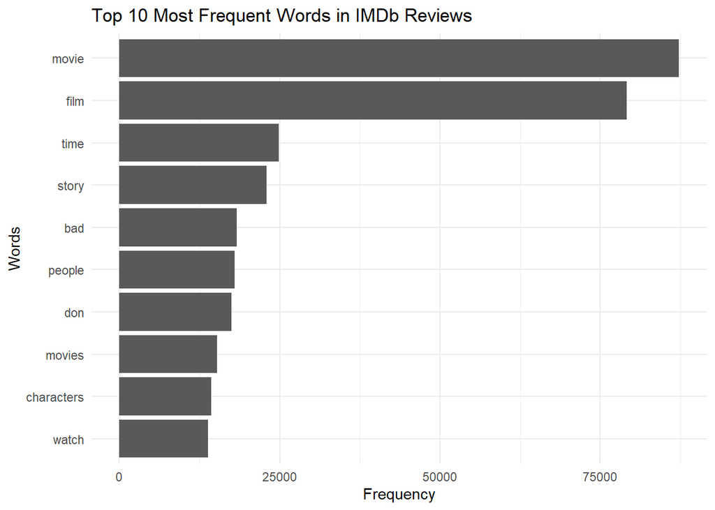

```r
top_words <- word_counts %>%
  slice_max(n, n = 10)

ggplot(top_words, aes(x = reorder(word, n), y = n)) +
  geom_col() +
  coord_flip() +
  labs(
    title = "Top 10 Most Frequent Words in IMDb Reviews",
    x = "Words",
    y = "Frequency"
  ) +
  theme_minimal()
```

# 8 7. Bing Lexicon Sentiment Analysis

The Bing sentiment lexicon assigns words a positive or negative sentiment label. The review tokens are matched with the lexicon to examine sentiment words in the reviews.

Some words in the original lexicon may appear more than once with conflicting sentiment labels. These ambiguous entries are excluded before the final join.

```r
bing_words <- get_sentiments("bing")

sum(duplicated(bing_words$word))
```

```
## [1] 3
```

```r
bing_words %>%
  count(word) %>%
  filter(n > 1)
```

| word | n |
| --- | --- |
| envious | 2 |
| enviously | 2 |
| enviousness | 2 |

```r
bing_words %>%
  filter(word %in% c("envious", "enviously", "enviousness"))
```

| word | sentiment |
| --- | --- |
| envious | positive |
| envious | negative |
| enviously | positive |
| enviously | negative |
| enviousness | positive |
| enviousness | negative |

```r
bing_clean <- bing_words %>%
  group_by(word) %>%
  filter(n_distinct(sentiment) == 1) %>%
  ungroup() %>%
  distinct(word, sentiment)

sum(duplicated(bing_clean$word))
```

```
## [1] 0
```

```r
review_sentiment_words <- reviews_tokens %>%
  inner_join(bing_clean, by = "word")

head(review_sentiment_words)
```

|  | sentiment.x | review_id | word | sentiment.y |
| --- | --- | --- | --- | --- |
| 1 | positive | 1 | struck | negative |
| 2 | positive | 1 | brutality | negative |
| 3 | positive | 1 | trust | positive |
| 4 | positive | 1 | faint | negative |
| 5 | positive | 1 | timid | negative |
| 6 | positive | 1 | classic | positive |

```r
sentiment_summary <- review_sentiment_words %>%
  count(sentiment.x, sentiment.y)

sentiment_summary
```

| sentiment.x | sentiment.y | n |
| --- | --- | --- |
| negative | negative | 276096 |
| negative | positive | 123543 |
| positive | negative | 188897 |
| positive | positive | 200079 |

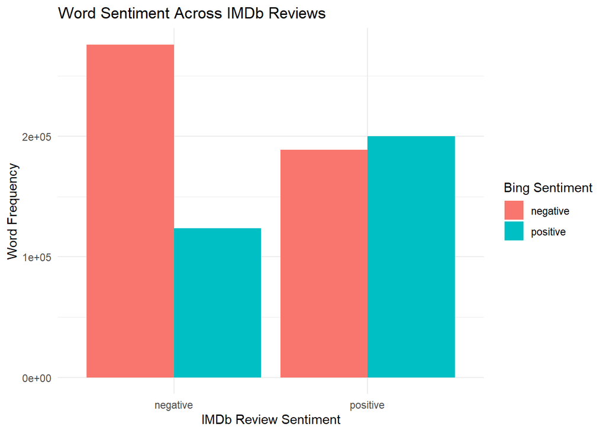

```r
ggplot(
  sentiment_summary,
  aes(x = sentiment.x, y = n, fill = sentiment.y)
) +
  geom_col(position = "dodge") +
  labs(
    title = "Word Sentiment Across IMDb Reviews",
    x = "IMDb Review Sentiment",
    y = "Word Frequency",
    fill = "Bing Sentiment"
  ) +
  theme_minimal()
```

# 9 8. Distribution of Review Word Counts

This section counts the words remaining in each review after tokenisation and stop-word removal. A histogram is used to show how review lengths are distributed.

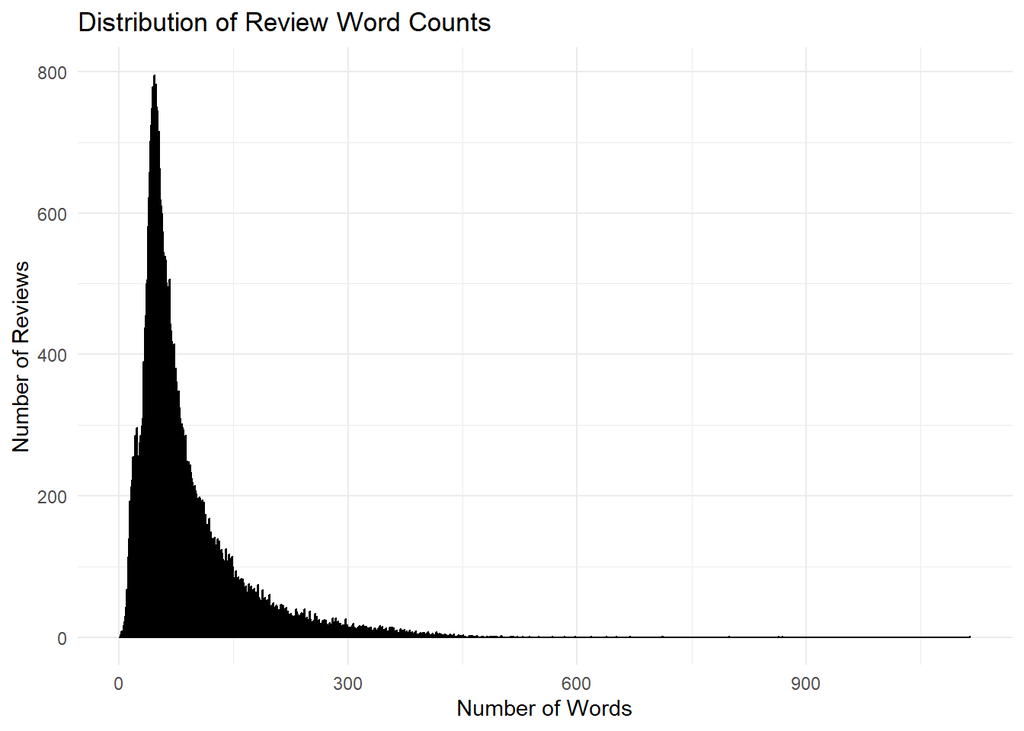

```r
reviews_processed$word_count <- stringr::str_count(
  stringr::str_trim(reviews_processed$review),
  "\\S+"
)

review_word_counts <- reviews_tokens %>%
  count(review_id, name = "word_count")

ggplot(review_word_counts, aes(x = word_count)) +
  geom_histogram(
    binwidth = 1,
    fill = "skyblue",
    color = "black"
  ) +
  labs(
    title = "Distribution of Review Word Counts",
    x = "Number of Words",
    y = "Number of Reviews"
  ) +
  theme_minimal()
```

# 10 9. Positive and Negative Word Frequencies

The most frequent words identified as positive and negative by the Bing lexicon are extracted separately. Bar charts are used to compare the ten most frequent words in each category.

```r
sentiment_word_counts <- review_sentiment_words %>%
  count(word, sentiment.y, sort = TRUE)

head(sentiment_word_counts, 10)
```

|  | word | sentiment.y | n |
| --- | --- | --- | --- |
| 1 | bad | negative | 18292 |
| 2 | love | positive | 12914 |
| 3 | plot | negative | 12889 |
| 4 | funny | negative | 8680 |
| 5 | pretty | positive | 7203 |
| 6 | fun | positive | 5341 |
| 7 | worst | negative | 5281 |
| 8 | hard | negative | 5234 |
| 9 | worth | positive | 4641 |
| 10 | beautiful | positive | 4189 |

```r
positive_words <- sentiment_word_counts %>%
  filter(sentiment.y == "positive") %>%
  slice_max(n, n = 10)

head(positive_words)
```

|  | word | sentiment.y | n |
| --- | --- | --- | --- |
| 1 | love | positive | 12914 |
| 2 | pretty | positive | 7203 |
| 3 | fun | positive | 5341 |
| 4 | worth | positive | 4641 |
| 5 | beautiful | positive | 4189 |
| 6 | excellent | positive | 4081 |

```r
negative_words <- sentiment_word_counts %>%
  filter(sentiment.y == "negative") %>%
  slice_max(n, n = 10)

head(negative_words)
```

|  | word | sentiment.y | n |
| --- | --- | --- | --- |
| 1 | bad | negative | 18292 |
| 2 | plot | negative | 12889 |
| 3 | funny | negative | 8680 |
| 4 | worst | negative | 5281 |
| 5 | hard | negative | 5234 |
| 6 | death | negative | 3914 |

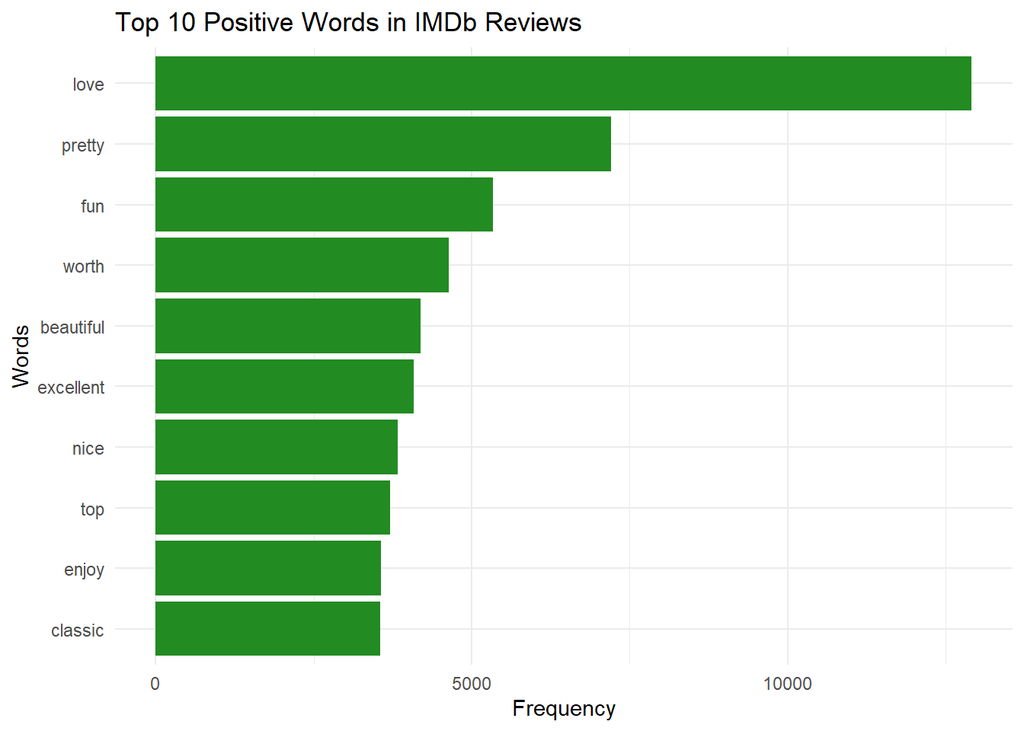

```r
ggplot(positive_words, aes(x = reorder(word, n), y = n)) +
  geom_col(fill = "forestgreen") +
  coord_flip() +
  labs(
    title = "Top 10 Positive Words in IMDb Reviews",
    x = "Words",
    y = "Frequency"
  ) +
  theme_minimal()
```

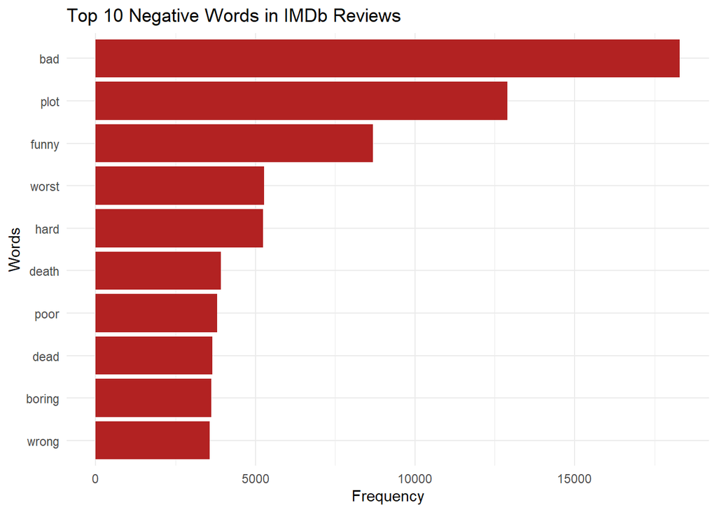

```r
ggplot(negative_words, aes(x = reorder(word, n), y = n)) +
  geom_col(fill = "firebrick") +
  coord_flip() +
  labs(
    title = "Top 10 Negative Words in IMDb Reviews",
    x = "Words",
    y = "Frequency"
  ) +
  theme_minimal()
```

# 11 10. Total Positive and Negative Word Counts

The total number of positive and negative words matched by the Bing lexicon is calculated and displayed in a bar chart.

```r
review_sentiment_count <- review_sentiment_words %>%
  count(sentiment.y, sort = TRUE)

head(review_sentiment_count)
```

|  | sentiment.y | n |
| --- | --- | --- |
| 1 | negative | 464993 |
| 2 | positive | 323622 |

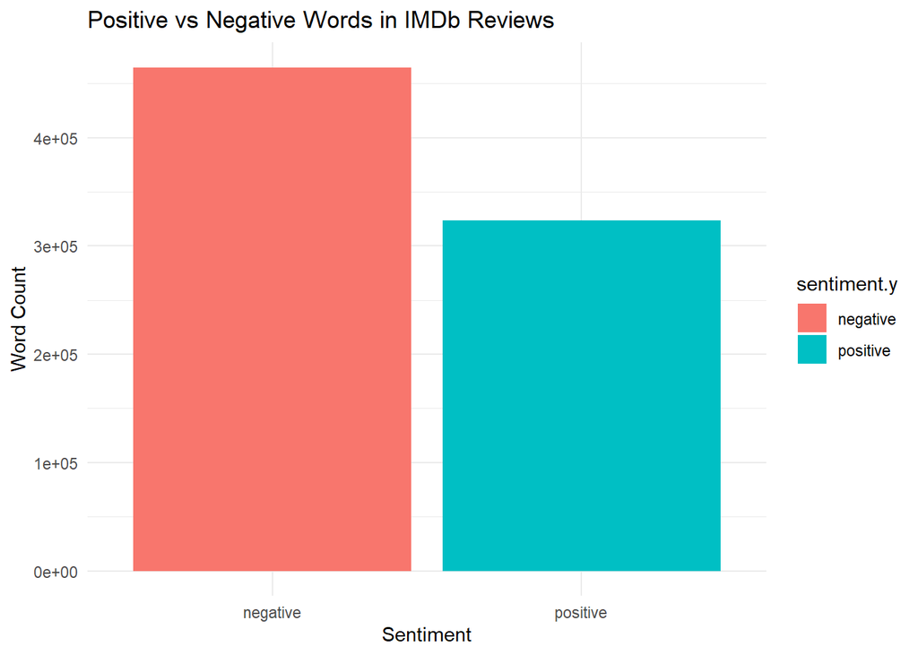

```r
ggplot(
  review_sentiment_count,
  aes(x = sentiment.y, y = n, fill = sentiment.y)
) +
  geom_col() +
  labs(
    title = "Positive vs Negative Words in IMDb Reviews",
    x = "Sentiment",
    y = "Word Count"
  ) +
  theme_minimal()
```

# 12 11. Compare Bing Word Sentiment Across Review Categories

This comparison examines how many positive and negative lexicon words occur in reviews labelled positive or negative in the original dataset. Percentages are calculated within each original review sentiment category.

```r
review_comparison <- review_sentiment_words %>%
  count(sentiment.x, sentiment.y)

review_comparison
```

| sentiment.x | sentiment.y | n |
| --- | --- | --- |
| negative | negative | 276096 |
| negative | positive | 123543 |
| positive | negative | 188897 |
| positive | positive | 200079 |

```r
review_comparison %>%
  group_by(sentiment.x) %>%
  mutate(percentage = round(n / sum(n) * 100, 2))
```

| sentiment.x | sentiment.y | n | percentage |
| --- | --- | --- | --- |
| negative | negative | 276096 | 69.09 |
| negative | positive | 123543 | 30.91 |
| positive | negative | 188897 | 48.56 |
| positive | positive | 200079 | 51.44 |

# 13 12. TF-IDF Analysis

Term Frequency–Inverse Document Frequency (TF-IDF) is used to identify words that are relatively important to individual reviews. Words that occur frequently in a particular review but less frequently across the collection can receive higher TF-IDF scores.

The analysis calculates TF-IDF scores, summarises the average score for each word, and filters out words that occur in fewer than ten reviews before selecting the top ten.

```r
tf_idf_words <- reviews_tokens %>%
  count(review_id, word, sort = TRUE) %>%
  bind_tf_idf(word, review_id, n)

glimpse(tf_idf_words)
```

```
## Rows: 3,605,911
## Columns: 6
## $ review_id <int> 5813, 12623, 40106, 5706, 13741, 39612, 39612, 32408, 48729,…
## $ word      <chr> "marty", "titanic", "custer", "rob", "prot", "hawk", "tony",…
## $ n         <int> 41, 37, 37, 35, 35, 35, 35, 33, 32, 31, 30, 30, 30, 29, 29, …
## $ tf        <dbl> 0.13311688, 0.05196629, 0.07489879, 0.05231689, 0.09695291, …
## $ idf       <dbl> 6.6066905, 5.9361858, 7.1225037, 5.0748108, 7.9210114, 6.750…
## $ tf_idf    <dbl> 0.87946205, 0.30848157, 0.53346688, 0.26549833, 0.76796509, …
```

```r
head(tf_idf_words, 10)
```

|  | review_id | word | n | tf | idf | tf_idf |
| --- | --- | --- | --- | --- | --- | --- |
| 1 | 5813 | marty | 41 | 0.13311688 | 6.606691 | 0.8794621 |
| 2 | 12623 | titanic | 37 | 0.05196629 | 5.936186 | 0.3084816 |
| 3 | 40106 | custer | 37 | 0.07489879 | 7.122504 | 0.5334669 |
| 4 | 5706 | rob | 35 | 0.05231689 | 5.074811 | 0.2654983 |
| 5 | 13741 | prot | 35 | 0.09695291 | 7.921011 | 0.7679651 |
| 6 | 39612 | hawk | 35 | 0.08620690 | 6.750940 | 0.5819776 |
| 7 | 39612 | tony | 35 | 0.08620690 | 4.660780 | 0.4017914 |
| 8 | 32408 | victor | 33 | 0.06333973 | 5.250702 | 0.3325780 |
| 9 | 48729 | match | 32 | 0.09411765 | 4.370437 | 0.4113352 |
| 10 | 41480 | scarlett | 31 | 0.08423913 | 6.507318 | 0.5481708 |

```r
tf_idf_words %>%
  arrange(desc(tf_idf)) %>%
  select(word, review_id, n, tf, idf, tf_idf) %>%
  head(10)
```

|  | word | review_id | n | tf | idf | tf_idf |
| --- | --- | --- | --- | --- | --- | --- |
| 1 | trivialboring | 18633 | 26 | 0.5306122 | 10.811383 | 5.736652 |
| 2 | cognac | 22723 | 12 | 0.4285714 | 9.425089 | 4.039324 |
| 3 | smallville | 38927 | 3 | 0.3750000 | 7.866944 | 2.950104 |
| 4 | blahblahblahblahblahblahblahblahblahblahblahblahblahblahblahblahblahblah | 44985 | 6 | 0.2500000 | 10.811383 | 2.702846 |
| 5 | ghoulies | 47164 | 5 | 0.3571429 | 7.479179 | 2.671135 |
| 6 | dalmations | 25935 | 5 | 0.2631579 | 8.865473 | 2.333019 |
| 7 | colombo | 47787 | 4 | 0.2500000 | 9.019624 | 2.254906 |
| 8 | tarzan | 27386 | 6 | 0.3750000 | 5.999199 | 2.249700 |
| 9 | amália | 13520 | 3 | 0.2142857 | 10.118236 | 2.168193 |
| 10 | bardwork | 31588 | 1 | 0.2000000 | 10.811383 | 2.162277 |

```r
top_tfidf_words <- tf_idf_words %>%
  group_by(word) %>%
  summarise(mean_tf_idf = mean(tf_idf), .groups = "drop") %>%
  arrange(desc(mean_tf_idf)) %>%
  slice_head(n = 10)

top_tfidf_words
```

| word | mean_tf_idf |
| --- | --- |
| trivialboring | 5.736652 |
| blahblahblahblahblahblahblahblahblahblahblahblahblahblahblahblahblahblah | 2.702846 |
| bardwork | 2.162277 |
| hrpuff | 1.544483 |
| compering | 1.351423 |
| lilla | 1.351423 |
| lilllie | 1.351423 |
| someplaces | 1.351423 |
| fbis | 1.201265 |
| cybersix | 1.179424 |

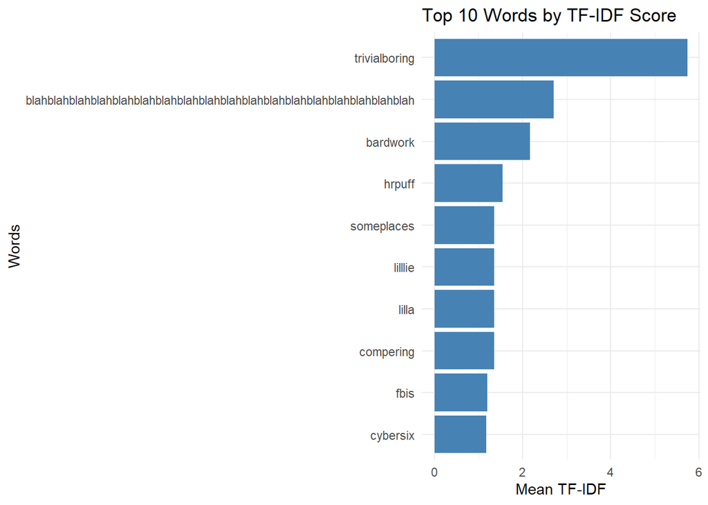

```r
ggplot(
  top_tfidf_words,
  aes(x = reorder(word, mean_tf_idf), y = mean_tf_idf)
) +
  geom_col(fill = "steelblue") +
  coord_flip() +
  labs(
    title = "Top 10 Words by TF-IDF Score",
    x = "Words",
    y = "Mean TF-IDF"
  ) +
  theme_minimal()
```

```r
tf_idf_words %>%
  arrange(desc(tf_idf)) %>%
  head(30)
```

|  | review_id | word | n | tf | idf | tf_idf |
| --- | --- | --- | --- | --- | --- | --- |
| 1 | 18633 | trivialboring | 26 | 0.5306122 | 10.811383 | 5.736652 |
| 2 | 22723 | cognac | 12 | 0.4285714 | 9.425089 | 4.039324 |
| 3 | 38927 | smallville | 3 | 0.3750000 | 7.866944 | 2.950104 |
| 4 | 44985 | blahblahblahblahblahblahblahblahblahblahblahblahblahblahblahblahblahblah | 6 | 0.2500000 | 10.811383 | 2.702846 |
| 5 | 47164 | ghoulies | 5 | 0.3571429 | 7.479179 | 2.671135 |
| 6 | 25935 | dalmations | 5 | 0.2631579 | 8.865473 | 2.333019 |
| 7 | 47787 | colombo | 4 | 0.2500000 | 9.019624 | 2.254906 |
| 8 | 27386 | tarzan | 6 | 0.3750000 | 5.999199 | 2.249700 |
| 9 | 13520 | amália | 3 | 0.2142857 | 10.118236 | 2.168193 |
| 10 | 31588 | bardwork | 1 | 0.2000000 | 10.811383 | 2.162277 |

[output cut: 20 more lines]

```r
names(tf_idf_words)
```

```
## [1] "review_id" "word"      "n"         "tf"        "idf"       "tf_idf"
```

```r
tf_idf_summary <- tf_idf_words %>%
  group_by(word) %>%
  summarise(mean_tf_idf = mean(tf_idf), .groups = "drop")

tf_idf_summary %>%
  arrange(desc(mean_tf_idf)) %>%
  head(30)
```

| word | mean_tf_idf |
| --- | --- |
| trivialboring | 5.736652 |
| blahblahblahblahblahblahblahblahblahblahblahblahblahblahblahblahblahblah | 2.702846 |
| bardwork | 2.162277 |
| hrpuff | 1.544483 |
| compering | 1.351423 |
| lilla | 1.351423 |
| lilllie | 1.351423 |
| someplaces | 1.351423 |
| fbis | 1.201265 |
| cybersix | 1.179424 |

[output cut: 20 more lines]

```r
tf_idf_words %>%
  filter(word %in% c("trivialboring", "barwork", "someplaces")) %>%
  select(review_id, word, tf_idf) %>%
  head(10)
```

|  | review_id | word | tf_idf |
| --- | --- | --- | --- |
| 1 | 18633 | trivialboring | 5.736652 |
| 2 | 23538 | someplaces | 1.351423 |

```r
reviews_processed[18633, "review"]
```

```
## [1] "i had to watch this movie for professional reasons and can only say it s a complete waste of time when running baldwin looks like an ape characters are dull same story has been told times better in other movies i think everything has been now said about this film but imdb requires me to writ…
```

```r
reviews_processed[23538, "review"]
```

```
## [1] "since this is part then compering it to part one man that was on many places wierd too many time jumps etc i have to say that i was really disapointed only someplaces little lame action and thats it they could have done that better"
```

```r
tf_idf_summary <- tf_idf_words %>%
  group_by(word) %>%
  summarise(
    document_frequency = n_distinct(review_id),
    mean_tf_idf = mean(tf_idf),
    .groups = "drop"
  ) %>%
  filter(document_frequency >= 10) %>%
  arrange(desc(mean_tf_idf))

top_tfidf_words <- tf_idf_summary %>%
  slice_head(n = 10)

top_tfidf_words
```

| word | document_frequency | mean_tf_idf |
| --- | --- | --- |
| ghoulies | 28 | 0.5505468 |
| brite | 14 | 0.4162736 |
| prue | 13 | 0.4011466 |
| lanza | 10 | 0.3996122 |
| dahmer | 23 | 0.3895537 |
| kuzco | 12 | 0.3820331 |
| shaq | 15 | 0.3735297 |
| pokemon | 32 | 0.3728368 |
| tweety | 17 | 0.3598788 |
| killjoy | 21 | 0.3517586 |

[figure not shown]

```r
ggplot(
  top_tfidf_words,
  aes(x = reorder(word, mean_tf_idf), y = mean_tf_idf)
) +
  geom_col(fill = "steelblue") +
  coord_flip() +
  labs(
    title = "Top 10 Words by TF-IDF Score",
    x = "Words",
    y = "Mean TF-IDF Score"
  ) +
  theme_minimal()
```

# 14 13. Word Clouds

Word clouds provide a visual representation of frequently occurring positive and negative words. The size of each word reflects its frequency in the corresponding sentiment category.

```r
positive_wordcloud <- sentiment_word_counts %>%
  filter(sentiment.y == "positive") %>%
  arrange(desc(n))

head(positive_wordcloud, 10)
```

|  | word | sentiment.y | n |
| --- | --- | --- | --- |
| 1 | love | positive | 12914 |
| 2 | pretty | positive | 7203 |
| 3 | fun | positive | 5341 |
| 4 | worth | positive | 4641 |
| 5 | beautiful | positive | 4189 |
| 6 | excellent | positive | 4081 |
| 7 | nice | positive | 3829 |
| 8 | top | positive | 3713 |
| 9 | enjoy | positive | 3566 |
| 10 | classic | positive | 3554 |

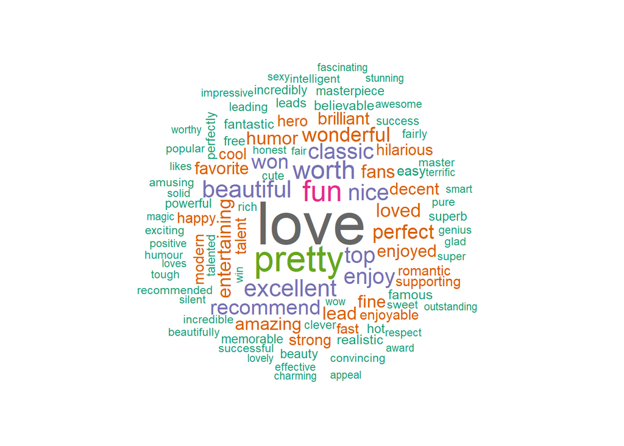

```r
wordcloud(
  words = positive_wordcloud$word,
  freq = positive_wordcloud$n,
  max.words = 100,
  random.order = FALSE,
  colors = brewer.pal(8, "Dark2")
)
```

```r
negative_wordcloud <- sentiment_word_counts %>%
  filter(sentiment.y == "negative") %>%
  arrange(desc(n))

head(negative_wordcloud, 10)
```

|  | word | sentiment.y | n |
| --- | --- | --- | --- |
| 1 | bad | negative | 18292 |
| 2 | plot | negative | 12889 |
| 3 | funny | negative | 8680 |
| 4 | worst | negative | 5281 |
| 5 | hard | negative | 5234 |
| 6 | death | negative | 3914 |
| 7 | poor | negative | 3802 |
| 8 | dead | negative | 3659 |
| 9 | boring | negative | 3623 |
| 10 | wrong | negative | 3562 |

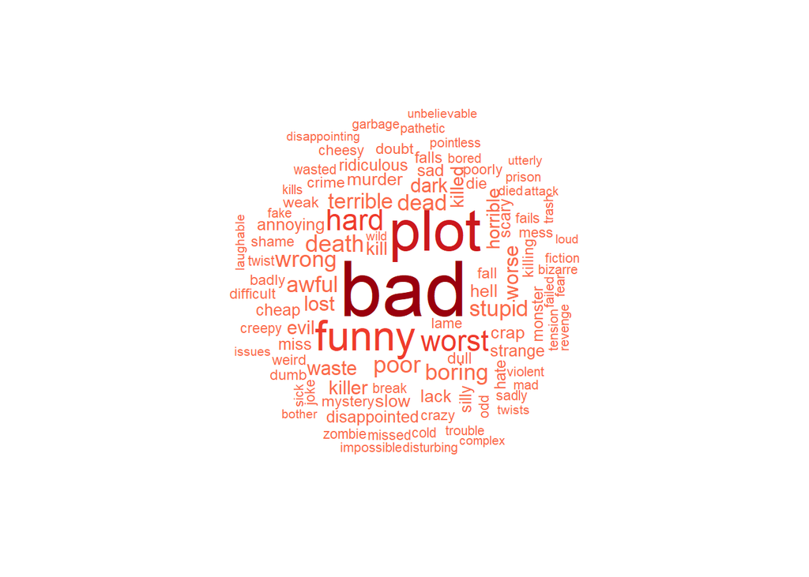

```r
wordcloud(
  words = negative_wordcloud$word,
  freq = negative_wordcloud$n,
  max.words = 100,
  random.order = FALSE,
  colors = brewer.pal(8, "Reds")[5:8]
)
```

# 15 14. Heatmap of Positive and Negative Words

A heatmap is created to compare the frequencies of the ten most frequent positive and negative words identified by the Bing lexicon. The colour intensity represents word frequency.

```r
heatmap_words <- sentiment_word_counts %>%
  group_by(sentiment.y) %>%
  slice_max(order_by = n, n = 10) %>%
  ungroup()

head(heatmap_words, 20)
```

| word | sentiment.y | n |
| --- | --- | --- |
| bad | negative | 18292 |
| plot | negative | 12889 |
| funny | negative | 8680 |
| worst | negative | 5281 |
| hard | negative | 5234 |
| death | negative | 3914 |
| poor | negative | 3802 |
| dead | negative | 3659 |
| boring | negative | 3623 |
| wrong | negative | 3562 |

[output cut: 10 more lines]

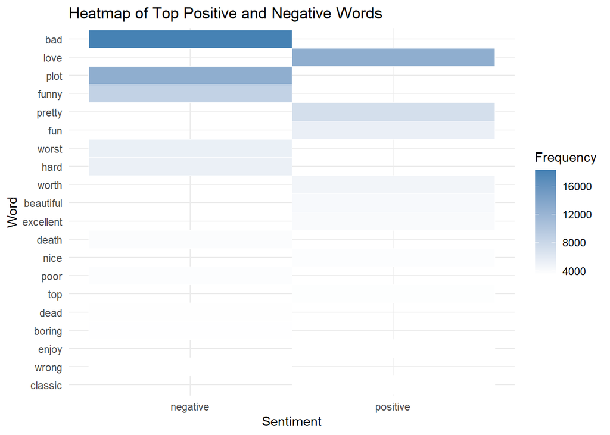

```r
ggplot(
  heatmap_words,
  aes(x = sentiment.y, y = reorder(word, n), fill = n)
) +
  geom_tile(color = "white") +
  scale_fill_gradient(low = "white", high = "steelblue") +
  labs(
    title = "Heatmap of Top Positive and Negative Words",
    x = "Sentiment",
    y = "Word",
    fill = "Frequency"
  ) +
  theme_minimal()
```

# 16 15. Prepare Data for Machine Learning

The processed reviews are divided into training and testing datasets. A fixed random seed is used to make the split reproducible. The split is performed within each sentiment category to retain the class balance.

```r
set.seed(123)

reviews_model <- reviews_processed %>%
  mutate(review_id = row_number())

train_data <- reviews_model %>%
  group_by(sentiment) %>%
  slice_sample(prop = 0.8) %>%
  ungroup()

test_data <- reviews_model %>%
  filter(!review_id %in% train_data$review_id)

dim(train_data)
```

```
## [1] 39665     4
```

```r
dim(test_data)
```

```
## [1] 9917    4
```

```r
table(train_data$sentiment)
```

```
##
## negative positive
##    19758    19907
```

```r
table(test_data$sentiment)
```

```
##
## negative positive
##     4940     4977
```

# 17 16. Create the Training Vocabulary and Document-Term Matrices

The training reviews are tokenised, and stop words are removed. A vocabulary is created and pruned to remove terms that occur too rarely or in too large a proportion of documents. The vocabulary is then used to create document-term matrices for the training and testing data.

The test data uses the training vocabulary so that both matrices contain the same features.

```r
tokens_train <- word_tokenizer(train_data$review)

tokens_train <- lapply(tokens_train, function(words) {
  words[!words %in% stop_words$word]
})

it_train <- itoken(
  tokens_train,
  progressbar = FALSE
)

vocab <- create_vocabulary(it_train)

vocab <- prune_vocabulary(
  vocab,
  term_count_min = 5,
  doc_proportion_max = 0.5
)

vocab
```

|  | term | term_count | doc_count |
| --- | --- | --- | --- |
| 55536 | aankhen | 5 | 4 |
| 55537 | abbie | 5 | 3 |
| 55538 | abductor | 5 | 5 |
| 55539 | abnormally | 5 | 5 |
| 55540 | abolished | 5 | 5 |
| 55541 | abominably | 5 | 5 |
| 55542 | aboriginals | 5 | 4 |
| 55543 | abrams | 5 | 5 |
| 55544 | abril | 5 | 4 |
| 55545 | absolutley | 5 | 4 |

[output cut: 9990 more lines]

```r
vectorizer <- vocab_vectorizer(vocab)

dtm_train <- create_dtm(
  it_train,
  vectorizer
)

dim(dtm_train)
```

```
## [1] 39665 35070
```

```r
tokens_test <- word_tokenizer(test_data$review)

tokens_test <- lapply(tokens_test, function(words) {
  words[!words %in% stop_words$word]
})

it_test <- itoken(
  tokens_test,
  progressbar = FALSE
)

dtm_test <- create_dtm(
  it_test,
  vectorizer
)

dim(dtm_test)
```

```
## [1]  9917 35070
```

```r
y_train <- ifelse(train_data$sentiment == "positive", 1, 0)
y_test <- ifelse(test_data$sentiment == "positive", 1, 0)

table(y_train)
```

```
## y_train
##     0     1
## 19758 19907
```

```r
table(y_test)
```

```
## y_test
##    0    1
## 4940 4977
```

# 18 17. Logistic Regression Model

A LASSO-regularised logistic regression model is trained using the training document-term matrix. The model predicts the probability that each test review belongs to the positive sentiment class. A probability threshold of 0.5 is used to assign predicted classes.

```r
set.seed(123)

logistic_model <- glmnet(
  x = dtm_train,
  y = y_train,
  family = "binomial",
  alpha = 1,
  nlambda = 20,
  maxit = 10000
)
print(logistic_model)
```

```
##
## Call:  glmnet(x = dtm_train, y = y_train, family = "binomial", alpha = 1,      nlambda = 20, maxit = 10000)
##
##    Df  %Dev   Lambda
## 1   0  0.00 0.129600
## 2   4  5.19 0.079780
## 3  18 12.70 0.049130
## 4  46 22.02 0.030260
## 5 109 31.03 0.018640
## 6 232 39.42 0.011480
## 7 466 46.61 0.007068
```

```r
length(logistic_model$lambda)
```

```
## [1] 7
```

```r
logistic_model$lambda
```

```
## [1] 0.12955049 0.07978344 0.04913449 0.03025939 0.01863519 0.01147645 0.00706775
```

```r
logistic_lambda <- logistic_model$lambda[7]

logistic_pred <- predict(
  logistic_model,
  newx = dtm_test,
  s = logistic_lambda,
  type = "response"
)

head(logistic_pred)
```

```
##   s=0.00706775
## 1   0.78504527
## 2   0.55920842
## 3   0.76936228
## 4   0.69347886
## 5   0.06296484
## 6   0.66218876
```

```r
logistic_class <- ifelse(logistic_pred >= 0.5, 1, 0)

head(logistic_class)
```

```
##   s=0.00706775
## 1            1
## 2            1
## 3            1
## 4            1
## 5            0
## 6            1
```

```r
logistic_accuracy <- mean(logistic_class == y_test)
logistic_accuracy
```

```
## [1] 0.8511647
```

```r
logistic_cm <- table(
  Actual = y_test,
  Predicted = logistic_class
)

logistic_cm
```

```
##       Predicted
## Actual    0    1
##      0 3997  943
##      1  533 4444
```

```r
precision <- 4444 / (4444 + 943)
recall <- 4444 / (4444 + 533)

f1_score <- 2 * (precision * recall) / (precision + recall)

precision
```

```
## [1] 0.824949
```

```r
recall
```

```
## [1] 0.8929074
```

```r
f1_score
```

```
## [1] 0.8575839
```

```r
logistic_result <- data.frame(
  Model = "Logistic Regression",
  Accuracy = logistic_accuracy,
  Precision = precision,
  Recall = recall,
  F1 = f1_score
)

logistic_result
```

| Model | Accuracy | Precision | Recall | F1 |
| --- | --- | --- | --- | --- |
| Logistic Regression | 0.8511647 | 0.824949 | 0.8929074 | 0.8575839 |

```r
write.csv(
  logistic_result,
  "logistic_regression_results.csv",
  row.names = FALSE
)
```